# MODELING BANKFRAUD

Jairo Onate

2024-09-27

#### Group 1 members: Jairo Onate, John Pole Madhu, Ajay Katta

### Cleaning and Preprocessing:

```r
library(readr)
bankfraud_base <- read_csv(file = '/Users/jairoonatebarrios/Documents/BDA 610 ADVANCED BUSINESS STATISTICS/PROJECT DATA/BANK FRAUD CSV/Base.csv', col_names = TRUE)
```

#### Filter the missing values stored as -1

```r
library(dplyr)

str(bankfraud_base)
```

```
## spc_tbl_ [1,000,000 × 32] (S3: spec_tbl_df/tbl_df/tbl/data.frame)
##  $ fraud_bool                      : num [1:1000000] 0 0 0 0 0 0 0 0 0 0 ...
##  $ income                          : num [1:1000000] 0.3 0.8 0.8 0.6 0.9 0.6 0.2 0.8 0.3 0.8 ...
##  $ name_email_similarity           : num [1:1000000] 0.987 0.617 0.997 0.475 0.842 ...
##  $ prev_address_months_count       : num [1:1000000] -1 -1 9 11 -1 -1 22 -1 21 -1 ...
##  $ current_address_months_count    : num [1:1000000] 25 89 14 14 29 369 4 103 2 134 ...
##  $ customer_age                    : num [1:1000000] 40 20 40 30 40 30 40 40 30 20 ...
##  $ days_since_request              : num [1:1000000] 0.00674 0.0101 0.01232 0.00699 5.74263 ...
##  $ intended_balcon_amount          : num [1:1000000] 102.45 -0.85 -1.49 -1.86 47.15 ...
##  $ payment_type                    : chr [1:1000000] "AA" "AD" "AB" "AB" ...
##  $ zip_count_4w                    : num [1:1000000] 1059 1658 1095 3483 2339 ...
##  $ velocity_6h                     : num [1:1000000] 13096 9223 4471 14432 7602 ...
##  $ velocity_24h                    : num [1:1000000] 7851 5745 5472 6755 5124 ...
##  $ velocity_4w                     : num [1:1000000] 6742 5942 5993 5970 5941 ...
##  $ bank_branch_count_8w            : num [1:1000000] 5 3 15 11 1 705 28 6 2 14 ...
##  $ date_of_birth_distinct_emails_4w: num [1:1000000] 5 18 11 13 6 5 8 7 10 20 ...
##  $ employment_status               : chr [1:1000000] "CB" "CA" "CA" "CA" ...
##  $ credit_risk_score               : num [1:1000000] 163 154 89 90 91 134 72 163 35 201 ...
##  $ email_is_free                   : num [1:1000000] 1 1 1 1 0 1 1 0 0 1 ...
##  $ housing_status                  : chr [1:1000000] "BC" "BC" "BC" "BC" ...
##  $ phone_home_valid                : num [1:1000000] 0 1 0 0 1 1 1 1 1 1 ...
##  $ phone_mobile_valid              : num [1:1000000] 1 1 1 1 1 1 1 1 0 1 ...
##  $ bank_months_count               : num [1:1000000] 9 2 30 1 26 30 1 25 2 15 ...
##  $ has_other_cards                 : num [1:1000000] 0 0 0 0 0 0 0 1 0 0 ...
##  $ proposed_credit_limit           : num [1:1000000] 1500 1500 200 200 200 200 200 200 200 1500 ...
##  $ foreign_request                 : num [1:1000000] 0 0 0 0 0 0 0 0 0 0 ...
##  $ source                          : chr [1:1000000] "INTERNET" "INTERNET" "INTERNET" "INTERNET" ...
##  $ session_length_in_minutes       : num [1:1000000] 16.22 3.36 22.73 15.22 3.74 ...
##  $ device_os                       : chr [1:1000000] "linux" "other" "windows" "linux" ...
##  $ keep_alive_session              : num [1:1000000] 1 1 0 1 0 1 1 1 1 1 ...
##  $ device_distinct_emails_8w       : num [1:1000000] 1 1 1 1 1 1 1 1 1 1 ...
##  $ device_fraud_count              : num [1:1000000] 0 0 0 0 0 0 0 0 0 0 ...
##  $ month                           : num [1:1000000] 0 0 0 0 0 0 0 0 0 0 ...
##  - attr(*, "spec")=
##   .. cols(
##   ..   fraud_bool = col_double(),
##   ..   income = col_double(),
##   ..   name_email_similarity = col_double(),
##   ..   prev_address_months_count = col_double(),
##   ..   current_address_months_count = col_double(),
```

[output cut: 14 more lines]

```
##   ..   phone_home_valid = col_double(),
##   ..   phone_mobile_valid = col_double(),
##   ..   bank_months_count = col_double(),
##   ..   has_other_cards = col_double(),
##   ..   proposed_credit_limit = col_double(),
##   ..   foreign_request = col_double(),
##   ..   source = col_character(),
##   ..   session_length_in_minutes = col_double(),
##   ..   device_os = col_character(),
##   ..   keep_alive_session = col_double(),
##   ..   device_distinct_emails_8w = col_double(),
##   ..   device_fraud_count = col_double(),
##   ..   month = col_double()
##   .. )
##  - attr(*, "problems")=<externalptr>
```

```r
which(is.na(bankfraud_base))
```

```
## integer(0)
```

```r
sum(is.na(bankfraud_base))
```

```
## [1] 0
```

```r
bankfraud_base_nomissing <- bankfraud_base %>%filter(
       prev_address_months_count > -1 ,
       current_address_months_count > -1,
       intended_balcon_amount > -1,
       velocity_6h > -1,
       bank_months_count > -1,
       session_length_in_minutes > -1,
       device_distinct_emails_8w > -1)
str(bankfraud_base_nomissing)
```

```
## spc_tbl_ [124,260 × 32] (S3: spec_tbl_df/tbl_df/tbl/data.frame)
##  $ fraud_bool                      : num [1:124260] 0 0 0 0 0 0 0 0 0 0 ...
##  $ income                          : num [1:124260] 0.2 0.3 0.2 0.6 0.6 0.9 0.7 0.7 0.8 0.6 ...
##  $ name_email_similarity           : num [1:124260] 0.7731 0.5237 0.5278 0.7729 0.0307 ...
##  $ prev_address_months_count       : num [1:124260] 22 21 13 96 48 49 26 235 287 90 ...
##  $ current_address_months_count    : num [1:124260] 4 2 114 124 5 8 14 29 13 35 ...
##  $ customer_age                    : num [1:124260] 40 30 20 40 20 20 20 30 30 20 ...
##  $ days_since_request              : num [1:124260] 0.00692 0.03521 0.00317 0.01549 0.00831 ...
##  $ intended_balcon_amount          : num [1:124260] -0.545 -0.956 -0.848 -0.96 -0.793 ...
##  $ payment_type                    : chr [1:124260] "AB" "AB" "AB" "AB" ...
##  $ zip_count_4w                    : num [1:124260] 1998 1781 4389 4033 3601 ...
##  $ velocity_6h                     : num [1:124260] 11724 6980 12256 7412 9483 ...
##  $ velocity_24h                    : num [1:124260] 7864 4336 5391 5991 5370 ...
##  $ velocity_4w                     : num [1:124260] 6339 6625 6331 6373 6373 ...
##  $ bank_branch_count_8w            : num [1:124260] 28 2 1839 0 5 ...
##  $ date_of_birth_distinct_emails_4w: num [1:124260] 8 10 18 3 16 11 13 23 15 14 ...
##  $ employment_status               : chr [1:124260] "CA" "CA" "CA" "CB" ...
##  $ credit_risk_score               : num [1:124260] 72 35 49 245 142 114 162 18 200 173 ...
##  $ email_is_free                   : num [1:124260] 1 0 0 0 1 1 0 1 1 1 ...
##  $ housing_status                  : chr [1:124260] "BC" "BC" "BB" "BA" ...
##  $ phone_home_valid                : num [1:124260] 1 1 1 0 1 0 0 0 0 1 ...
##  $ phone_mobile_valid              : num [1:124260] 1 0 1 1 1 1 1 1 1 1 ...
##  $ bank_months_count               : num [1:124260] 1 2 15 28 20 1 20 11 1 3 ...
##  $ has_other_cards                 : num [1:124260] 0 0 0 0 0 0 0 0 0 0 ...
##  $ proposed_credit_limit           : num [1:124260] 200 200 200 1500 500 500 500 1000 1500 200 ...
##  $ foreign_request                 : num [1:124260] 0 0 0 0 0 0 0 0 0 0 ...
##  $ source                          : chr [1:124260] "INTERNET" "INTERNET" "INTERNET" "INTERNET" ...
##  $ session_length_in_minutes       : num [1:124260] 28.2 5.33 2.84 4.61 3.1 ...
##  $ device_os                       : chr [1:124260] "x11" "other" "windows" "other" ...
##  $ keep_alive_session              : num [1:124260] 1 1 1 1 1 1 1 1 1 1 ...
##  $ device_distinct_emails_8w       : num [1:124260] 1 1 2 1 1 1 1 1 1 1 ...
##  $ device_fraud_count              : num [1:124260] 0 0 0 0 0 0 0 0 0 0 ...
##  $ month                           : num [1:124260] 0 0 0 0 0 0 0 0 0 0 ...
##  - attr(*, "spec")=
##   .. cols(
##   ..   fraud_bool = col_double(),
##   ..   income = col_double(),
##   ..   name_email_similarity = col_double(),
##   ..   prev_address_months_count = col_double(),
##   ..   current_address_months_count = col_double(),
```

[output cut: 14 more lines]

```
##   ..   phone_home_valid = col_double(),
##   ..   phone_mobile_valid = col_double(),
##   ..   bank_months_count = col_double(),
##   ..   has_other_cards = col_double(),
##   ..   proposed_credit_limit = col_double(),
##   ..   foreign_request = col_double(),
##   ..   source = col_character(),
##   ..   session_length_in_minutes = col_double(),
##   ..   device_os = col_character(),
##   ..   keep_alive_session = col_double(),
##   ..   device_distinct_emails_8w = col_double(),
##   ..   device_fraud_count = col_double(),
##   ..   month = col_double()
##   .. )
##  - attr(*, "problems")=<externalptr>
```

#### Dictionary

- **income (numeric):** Annual income of the applicant (in decile form). Ranges between [0.1, 0.9].
- **name_email_similarity (numeric):** Metric of similarity between email and applicant’s name. Higher values represent higher similarity. Ranges between [0, 1].
- **prev_address_months_count (numeric):** Number of months in previous registered address of the applicant, i.e. the applicant’s previous residence, if applicable. Ranges between [−1, 380] months (-1 is a missing value).
- **current_address_months_count (numeric):** Months in currently registered address of the applicant. Ranges between [−1, 429] months (-1 is a missing value).
- **customer_age (numeric):** Applicant’s age in years, rounded to the decade. Ranges between [10, 90] years.
- **days_since_request (numeric):** Number of days passed since application was done. Ranges between [0, 79] days.
- **intended_balcon_amount (numeric):** Initial transferred amount for application. Ranges between [−16, 114] (negatives are missing values).
- **payment_type (categorical):** Credit payment plan type. 5 possible (annonymized) values.
- **zip_count_4w (numeric):** Number of applications within same zip code in last 4 weeks. Ranges between [1, 6830].
- **velocity_6h (numeric):** Velocity of total applications made in last 6 hours i.e., average number of applications per hour in the last 6 hours. Ranges between [−175, 16818].
- **velocity_24h(numeric):** Velocity of total applications made in last 24 hours i.e.,average number of applications per hour in the last 24 hours. Ranges between [1297, 9586]
- **velocity_4w (numeric):** Velocity of total applications made in last 4 weeks, i.e., average number of applications per hour in the last 4 weeks. Ranges between [2825, 7020].
- **bank_branch_count_8w (numeric):** Number of total applications in the selected bank branch in last 8 weeks. Ranges between [0, 2404].
- **date_of_birth_distinct_emails_4w (numeric):** Number of emails for applicants with same date of birth in last 4 weeks. Ranges between [0, 39].
- **employment_status (categorical):** Employment status of the applicant. 7 possible (annonymized) values.
- **credit_risk_score (numeric):** Internal score of application risk. Ranges between [−191, 389].
- **email_is_free (binary):** Domain of application email (either free or paid).
- **housing_status (categorical):** Current residential status for applicant. 7 possible (annonymized) values.
- **phone_home_valid (binary):** Validity of provided home phone.
- **phone_mobile_valid (binary):** Validity of provided mobile phone.
- **bank_months_count (numeric):** How old is previous account (if held) in months. Ranges between [−1, 32] months (-1 is a missing value).
- **has_other_cards (binary):** If applicant has other cards from the same banking com- pany.
- **proposed_credit_limit (numeric):** Applicant’s proposed credit limit. Ranges between [200, 2000].
- **foreign_request (binary):** If origin country of request is different from bank’s country. - source (categorical): Online source of application. Either browser (INTERNET) or app (TELEAPP).
- **session_length_in_minutes (numeric):** Length of user session in banking website in minutes. Ranges between [−1, 107] minutes (-1 is a missing value).
- **device_os (categorical):** Operative system of device that made request. Possible values are: Windows, macOS, Linux, X11, or other.
- **keep_alive_session (binary):** User option on session logout.
- **device_distinct_emails (numeric):** Number of distinct emails in banking website from the used device in last 8 weeks. Ranges between [−1, 2] emails (-1 is a missing value). - device_fraud_count (numeric): Number of fraudulent applications with used device. Ranges between [0, 1].
- **month (numeric):** Month where the application was made. Ranges between [0, 7].
- **fraud_bool (binary):** If the application is fraudulent or not.

### Steps for the classification tasks

1. Feature selection: The aim is to select the best variables to build our models with.
2. Data partitioning
3. Class balancing
4. Deploying the model

### 1. Feature selection

The following code was implemented to run the Boruta package and perform the feature selection. These lines have been excluded from the R-chunk due to its high processing time.

install.packages(‘Boruta’) library(Boruta) set.seed(555) bankfraud_selection_br <- Boruta(fraud_bool ~ ., data = bankfraud_base_nomissing, doTrace = 2, maxRuns = 20)

print(bankfraud_selection_br) plot(bankfraud_selection_br, las = 2, cex.axis = 0.7, xlab = ‘Attributes’, ylab = ‘Importance’)

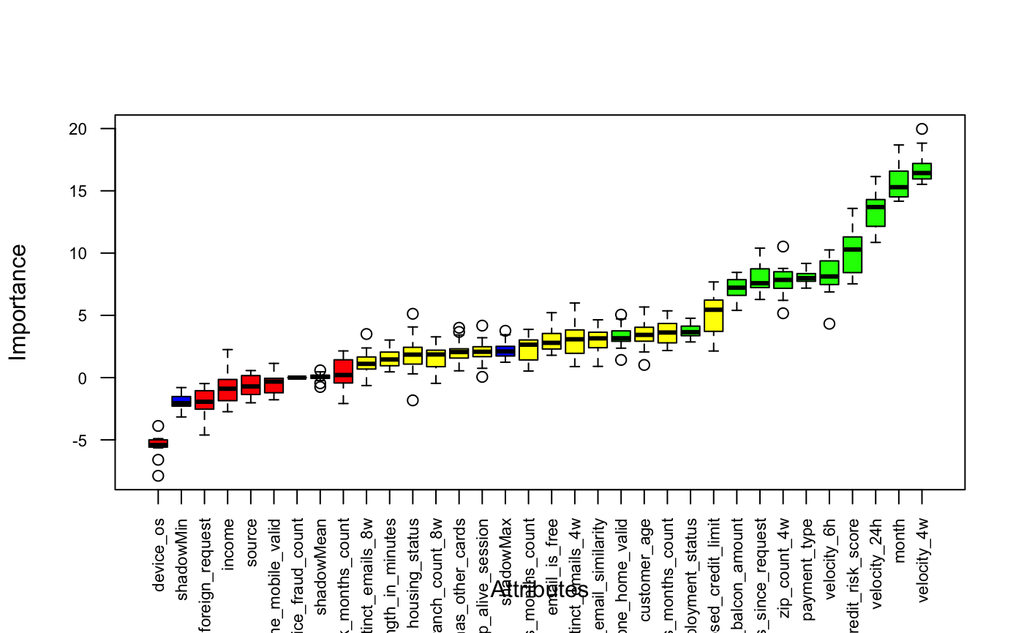

The green variables are the ones Boruta has selected as important to be fitted on a model, followed by the yellow variables where Boruta was undecided and the red variables have been rejected.

The following variables have been selected and marked with green: 1. phone_home_valid  
2. employment_status  
3. intended_balcon_amount  
4. days_since_request  
5. zip_count_4w  
6. payment_type  
7. velocity_6h  
8. velocity_6h  
9. credit_risk_score  
10. velocity_24h  
11. month  
12. velocity_4w

### 2. Data Partition

```r
nrows_bankfraud <- nrow(bankfraud_base_nomissing)
set.seed(128)
index <- sample(1:nrows_bankfraud, 0.7 * nrows_bankfraud) # We are using a 70-30 rule to approach the partition for training and testing

train_bankfraud <- bankfraud_base_nomissing[index,]
test_bankfraud <- bankfraud_base_nomissing[-index,]

table(train_bankfraud$fraud_bool)
```

```
##
##     0     1
## 86786   196
```

```r
# Count of total number of fraudulent = 1 and non fraudulent = 0 applications
bankfraud_base %>%  count(fraud_bool == 1) # Initial data set
```

```
## # A tibble: 2 × 2
##   `fraud_bool == 1`      n
##   <lgl>              <int>
## 1 FALSE             988971
## 2 TRUE               11029
```

```r
bankfraud_base_nomissing %>%  count(fraud_bool == 1) # Filtered data set with no missing values
```

```
## # A tibble: 2 × 2
##   `fraud_bool == 1`      n
##   <lgl>              <int>
## 1 FALSE             123972
## 2 TRUE                 288
```

We might face issues of class balancing since $99.77\%$ of the belonging to the portioned set for training has been classified as a non-fraud, therefore the model might not be able to fit accurately a fraudulent application.

### 3. Class balancing

To solve the issue of imbalance data we use the method `upSample` from the library `caret`to create more records

```r
# install.packages('caret')
library(caret)
str(bankfraud_base_nomissing)
```

```
## spc_tbl_ [124,260 × 32] (S3: spec_tbl_df/tbl_df/tbl/data.frame)
##  $ fraud_bool                      : num [1:124260] 0 0 0 0 0 0 0 0 0 0 ...
##  $ income                          : num [1:124260] 0.2 0.3 0.2 0.6 0.6 0.9 0.7 0.7 0.8 0.6 ...
##  $ name_email_similarity           : num [1:124260] 0.7731 0.5237 0.5278 0.7729 0.0307 ...
##  $ prev_address_months_count       : num [1:124260] 22 21 13 96 48 49 26 235 287 90 ...
##  $ current_address_months_count    : num [1:124260] 4 2 114 124 5 8 14 29 13 35 ...
##  $ customer_age                    : num [1:124260] 40 30 20 40 20 20 20 30 30 20 ...
##  $ days_since_request              : num [1:124260] 0.00692 0.03521 0.00317 0.01549 0.00831 ...
##  $ intended_balcon_amount          : num [1:124260] -0.545 -0.956 -0.848 -0.96 -0.793 ...
##  $ payment_type                    : chr [1:124260] "AB" "AB" "AB" "AB" ...
##  $ zip_count_4w                    : num [1:124260] 1998 1781 4389 4033 3601 ...
##  $ velocity_6h                     : num [1:124260] 11724 6980 12256 7412 9483 ...
##  $ velocity_24h                    : num [1:124260] 7864 4336 5391 5991 5370 ...
##  $ velocity_4w                     : num [1:124260] 6339 6625 6331 6373 6373 ...
##  $ bank_branch_count_8w            : num [1:124260] 28 2 1839 0 5 ...
##  $ date_of_birth_distinct_emails_4w: num [1:124260] 8 10 18 3 16 11 13 23 15 14 ...
##  $ employment_status               : chr [1:124260] "CA" "CA" "CA" "CB" ...
##  $ credit_risk_score               : num [1:124260] 72 35 49 245 142 114 162 18 200 173 ...
##  $ email_is_free                   : num [1:124260] 1 0 0 0 1 1 0 1 1 1 ...
##  $ housing_status                  : chr [1:124260] "BC" "BC" "BB" "BA" ...
##  $ phone_home_valid                : num [1:124260] 1 1 1 0 1 0 0 0 0 1 ...
##  $ phone_mobile_valid              : num [1:124260] 1 0 1 1 1 1 1 1 1 1 ...
##  $ bank_months_count               : num [1:124260] 1 2 15 28 20 1 20 11 1 3 ...
##  $ has_other_cards                 : num [1:124260] 0 0 0 0 0 0 0 0 0 0 ...
##  $ proposed_credit_limit           : num [1:124260] 200 200 200 1500 500 500 500 1000 1500 200 ...
##  $ foreign_request                 : num [1:124260] 0 0 0 0 0 0 0 0 0 0 ...
##  $ source                          : chr [1:124260] "INTERNET" "INTERNET" "INTERNET" "INTERNET" ...
##  $ session_length_in_minutes       : num [1:124260] 28.2 5.33 2.84 4.61 3.1 ...
##  $ device_os                       : chr [1:124260] "x11" "other" "windows" "other" ...
##  $ keep_alive_session              : num [1:124260] 1 1 1 1 1 1 1 1 1 1 ...
##  $ device_distinct_emails_8w       : num [1:124260] 1 1 2 1 1 1 1 1 1 1 ...
##  $ device_fraud_count              : num [1:124260] 0 0 0 0 0 0 0 0 0 0 ...
##  $ month                           : num [1:124260] 0 0 0 0 0 0 0 0 0 0 ...
##  - attr(*, "spec")=
##   .. cols(
##   ..   fraud_bool = col_double(),
##   ..   income = col_double(),
##   ..   name_email_similarity = col_double(),
##   ..   prev_address_months_count = col_double(),
##   ..   current_address_months_count = col_double(),
```

[output cut: 14 more lines]

```
##   ..   phone_home_valid = col_double(),
##   ..   phone_mobile_valid = col_double(),
##   ..   bank_months_count = col_double(),
##   ..   has_other_cards = col_double(),
##   ..   proposed_credit_limit = col_double(),
##   ..   foreign_request = col_double(),
##   ..   source = col_character(),
##   ..   session_length_in_minutes = col_double(),
##   ..   device_os = col_character(),
##   ..   keep_alive_session = col_double(),
##   ..   device_distinct_emails_8w = col_double(),
##   ..   device_fraud_count = col_double(),
##   ..   month = col_double()
##   .. )
##  - attr(*, "problems")=<externalptr>
```

```r
# First we convert the outcome variable fraud_bool as a factor before using the function upSample
bankfraud_base_nomissing$fraud_bool <- as.factor(bankfraud_base_nomissing$fraud_bool)
str(bankfraud_base_nomissing)
```

```
## spc_tbl_ [124,260 × 32] (S3: spec_tbl_df/tbl_df/tbl/data.frame)
##  $ fraud_bool                      : Factor w/ 2 levels "0","1": 1 1 1 1 1 1 1 1 1 1 ...
##  $ income                          : num [1:124260] 0.2 0.3 0.2 0.6 0.6 0.9 0.7 0.7 0.8 0.6 ...
##  $ name_email_similarity           : num [1:124260] 0.7731 0.5237 0.5278 0.7729 0.0307 ...
##  $ prev_address_months_count       : num [1:124260] 22 21 13 96 48 49 26 235 287 90 ...
##  $ current_address_months_count    : num [1:124260] 4 2 114 124 5 8 14 29 13 35 ...
##  $ customer_age                    : num [1:124260] 40 30 20 40 20 20 20 30 30 20 ...
##  $ days_since_request              : num [1:124260] 0.00692 0.03521 0.00317 0.01549 0.00831 ...
##  $ intended_balcon_amount          : num [1:124260] -0.545 -0.956 -0.848 -0.96 -0.793 ...
##  $ payment_type                    : chr [1:124260] "AB" "AB" "AB" "AB" ...
##  $ zip_count_4w                    : num [1:124260] 1998 1781 4389 4033 3601 ...
##  $ velocity_6h                     : num [1:124260] 11724 6980 12256 7412 9483 ...
##  $ velocity_24h                    : num [1:124260] 7864 4336 5391 5991 5370 ...
##  $ velocity_4w                     : num [1:124260] 6339 6625 6331 6373 6373 ...
##  $ bank_branch_count_8w            : num [1:124260] 28 2 1839 0 5 ...
##  $ date_of_birth_distinct_emails_4w: num [1:124260] 8 10 18 3 16 11 13 23 15 14 ...
##  $ employment_status               : chr [1:124260] "CA" "CA" "CA" "CB" ...
##  $ credit_risk_score               : num [1:124260] 72 35 49 245 142 114 162 18 200 173 ...
##  $ email_is_free                   : num [1:124260] 1 0 0 0 1 1 0 1 1 1 ...
##  $ housing_status                  : chr [1:124260] "BC" "BC" "BB" "BA" ...
##  $ phone_home_valid                : num [1:124260] 1 1 1 0 1 0 0 0 0 1 ...
##  $ phone_mobile_valid              : num [1:124260] 1 0 1 1 1 1 1 1 1 1 ...
##  $ bank_months_count               : num [1:124260] 1 2 15 28 20 1 20 11 1 3 ...
##  $ has_other_cards                 : num [1:124260] 0 0 0 0 0 0 0 0 0 0 ...
##  $ proposed_credit_limit           : num [1:124260] 200 200 200 1500 500 500 500 1000 1500 200 ...
##  $ foreign_request                 : num [1:124260] 0 0 0 0 0 0 0 0 0 0 ...
##  $ source                          : chr [1:124260] "INTERNET" "INTERNET" "INTERNET" "INTERNET" ...
##  $ session_length_in_minutes       : num [1:124260] 28.2 5.33 2.84 4.61 3.1 ...
##  $ device_os                       : chr [1:124260] "x11" "other" "windows" "other" ...
##  $ keep_alive_session              : num [1:124260] 1 1 1 1 1 1 1 1 1 1 ...
##  $ device_distinct_emails_8w       : num [1:124260] 1 1 2 1 1 1 1 1 1 1 ...
##  $ device_fraud_count              : num [1:124260] 0 0 0 0 0 0 0 0 0 0 ...
##  $ month                           : num [1:124260] 0 0 0 0 0 0 0 0 0 0 ...
##  - attr(*, "spec")=
##   .. cols(
##   ..   fraud_bool = col_double(),
##   ..   income = col_double(),
##   ..   name_email_similarity = col_double(),
##   ..   prev_address_months_count = col_double(),
##   ..   current_address_months_count = col_double(),
```

[output cut: 14 more lines]

```
##   ..   phone_home_valid = col_double(),
##   ..   phone_mobile_valid = col_double(),
##   ..   bank_months_count = col_double(),
##   ..   has_other_cards = col_double(),
##   ..   proposed_credit_limit = col_double(),
##   ..   foreign_request = col_double(),
##   ..   source = col_character(),
##   ..   session_length_in_minutes = col_double(),
##   ..   device_os = col_character(),
##   ..   keep_alive_session = col_double(),
##   ..   device_distinct_emails_8w = col_double(),
##   ..   device_fraud_count = col_double(),
##   ..   month = col_double()
##   .. )
##  - attr(*, "problems")=<externalptr>
```

```r
bankfraud_upsample <- upSample(x = bankfraud_base_nomissing, y = bankfraud_base_nomissing$fraud_bool)
str(bankfraud_upsample)
```

```
## 'data.frame':    247944 obs. of  33 variables:
##  $ fraud_bool                      : Factor w/ 2 levels "0","1": 1 1 1 1 1 1 1 1 1 1 ...
##  $ income                          : num  0.2 0.3 0.2 0.6 0.6 0.9 0.7 0.7 0.8 0.6 ...
##  $ name_email_similarity           : num  0.7731 0.5237 0.5278 0.7729 0.0307 ...
##  $ prev_address_months_count       : num  22 21 13 96 48 49 26 235 287 90 ...
##  $ current_address_months_count    : num  4 2 114 124 5 8 14 29 13 35 ...
##  $ customer_age                    : num  40 30 20 40 20 20 20 30 30 20 ...
##  $ days_since_request              : num  0.00692 0.03521 0.00317 0.01549 0.00831 ...
##  $ intended_balcon_amount          : num  -0.545 -0.956 -0.848 -0.96 -0.793 ...
##  $ payment_type                    : chr  "AB" "AB" "AB" "AB" ...
##  $ zip_count_4w                    : num  1998 1781 4389 4033 3601 ...
##  $ velocity_6h                     : num  11724 6980 12256 7412 9483 ...
##  $ velocity_24h                    : num  7864 4336 5391 5991 5370 ...
##  $ velocity_4w                     : num  6339 6625 6331 6373 6373 ...
##  $ bank_branch_count_8w            : num  28 2 1839 0 5 ...
```

[output cut: 19 more lines]

```r
bankfraud_upsample %>% count(fraud_bool == 1)
```

```
##   fraud_bool == 1      n
## 1           FALSE 123972
## 2            TRUE 123972
```

```r
# Portioning the data into training and testing sets

nrows_bankfraud_upsample <- nrow(bankfraud_upsample)
set.seed(128)
index_up <- sample(1:nrows_bankfraud_upsample, 0.7 * nrows_bankfraud_upsample) # We are using a 70-30 rule to approach the partition for training and testing

train_bankfraud_upsample <- bankfraud_upsample[index_up,]
test_bankfraud_upsample <- bankfraud_upsample[-index_up,]

table(train_bankfraud_upsample$fraud_bool)
```

```
##
##     0     1
## 86715 86845
```

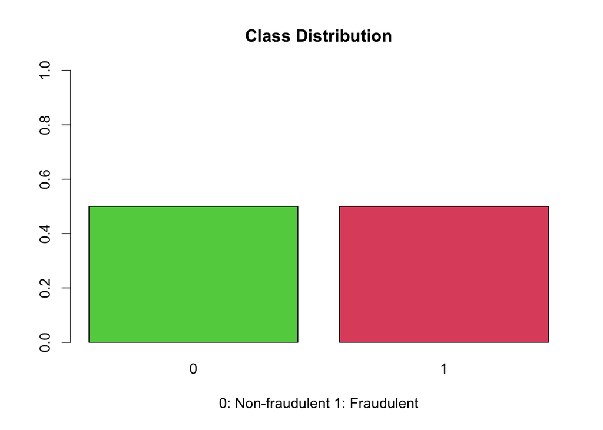

```r
barplot(prop.table(table(bankfraud_upsample$fraud_bool)),
        col = c(3,2),
        ylim = c(0,1),
        xlab = ('0: Non-fraudulent 1: Fraudulent'),
        main = 'Class Distribution')
```

### 4. Modeling

#### 4.1 Decision Tree

```r
# install.packages('partykit')
library(partykit) # Loading the package to obtain ctree functionality
str(bankfraud_upsample)
```

```
## 'data.frame':    247944 obs. of  33 variables:
##  $ fraud_bool                      : Factor w/ 2 levels "0","1": 1 1 1 1 1 1 1 1 1 1 ...
##  $ income                          : num  0.2 0.3 0.2 0.6 0.6 0.9 0.7 0.7 0.8 0.6 ...
##  $ name_email_similarity           : num  0.7731 0.5237 0.5278 0.7729 0.0307 ...
##  $ prev_address_months_count       : num  22 21 13 96 48 49 26 235 287 90 ...
##  $ current_address_months_count    : num  4 2 114 124 5 8 14 29 13 35 ...
##  $ customer_age                    : num  40 30 20 40 20 20 20 30 30 20 ...
##  $ days_since_request              : num  0.00692 0.03521 0.00317 0.01549 0.00831 ...
##  $ intended_balcon_amount          : num  -0.545 -0.956 -0.848 -0.96 -0.793 ...
##  $ payment_type                    : chr  "AB" "AB" "AB" "AB" ...
##  $ zip_count_4w                    : num  1998 1781 4389 4033 3601 ...
##  $ velocity_6h                     : num  11724 6980 12256 7412 9483 ...
##  $ velocity_24h                    : num  7864 4336 5391 5991 5370 ...
##  $ velocity_4w                     : num  6339 6625 6331 6373 6373 ...
##  $ bank_branch_count_8w            : num  28 2 1839 0 5 ...
```

[output cut: 19 more lines]

```r
bankfraud_upsample$payment_type <- as.factor(bankfraud_upsample$payment_type)
bankfraud_upsample$employment_status <- as.factor(bankfraud_upsample$employment_status)
bankfraud_upsample$housing_status <- as.factor(bankfraud_upsample$housing_status)
bankfraud_upsample$source <- as.factor(bankfraud_upsample$source)
bankfraud_upsample$device_os <- as.factor(bankfraud_upsample$device_os)

decisiontree_bankfraud <- ctree(fraud_bool ~
                            phone_home_valid +
                            intended_balcon_amount +
                            days_since_request +
                            zip_count_4w +
                            velocity_6h +
                            velocity_6h +
                            credit_risk_score +
                            velocity_24h +
                            month +
                            velocity_4w +
                            proposed_credit_limit +
                            proposed_credit_limit +
                            bank_months_count +
                            customer_age +
                            email_is_free +
                            session_length_in_minutes,
                            data = train_bankfraud_upsample, control = ctree_control(maxdepth = 7))

decisiontree_bankfraud_predict <- predict(decisiontree_bankfraud, test_bankfraud_upsample)
(confusion_matrix_decisiontree_predict <- confusionMatrix(data = decisiontree_bankfraud_predict, reference = test_bankfraud_upsample$fraud_bool, positive = "1"))
```

```
## Confusion Matrix and Statistics
##
##           Reference
## Prediction     0     1
##          0 29456  8405
##          1  7801 28722
##
##                Accuracy : 0.7821
##                  95% CI : (0.7791, 0.7851)
##     No Information Rate : 0.5009
##     P-Value [Acc > NIR] : < 2.2e-16
##
##                   Kappa : 0.5642
##
##  Mcnemar's Test P-Value : 2.172e-06
##
##             Sensitivity : 0.7736
##             Specificity : 0.7906
##          Pos Pred Value : 0.7864
##          Neg Pred Value : 0.7780
##              Prevalence : 0.4991
##          Detection Rate : 0.3861
##    Detection Prevalence : 0.4910
##       Balanced Accuracy : 0.7821
##
##        'Positive' Class : 1
##
```

By implementing the Decision Tree classification model an accuracy of 0.7821 has been calculated, were $28,722$ records ($38.61\%$) out of $74,384$ have been fitted as positive fraudulent records and the real value from the dataset was also reported as fraudulent. The fitted records classified as false negative were $8,405$ ($11.29\%$) and $7,801$ ($10.48\%$) records have been fitted as positive, even though the true value of the observation was reported as non-fraudulent.

#### 4.2 Logistic Regression

The `glm` function (generalized linear model) to perform a Logistic Regression by specifying the parameter $family = \ 'binomial'$.

```r
logistic_bankfraud <- glm(fraud_bool ~
                            phone_home_valid +
                            employment_status +
                            intended_balcon_amount +
                            days_since_request +
                            zip_count_4w +
                            payment_type +
                            velocity_6h +
                            velocity_6h +
                            credit_risk_score +
                            velocity_24h +
                            month +
                            velocity_4w +
                            proposed_credit_limit +
                            proposed_credit_limit +
                            bank_months_count +
                            customer_age +
                            email_is_free +
                            session_length_in_minutes ,
                        data = train_bankfraud_upsample, family = 'binomial')

summary(logistic_bankfraud)
```

```
##
## Call:
## glm(formula = fraud_bool ~ phone_home_valid + employment_status +
##     intended_balcon_amount + days_since_request + zip_count_4w +
##     payment_type + velocity_6h + velocity_6h + credit_risk_score +
##     velocity_24h + month + velocity_4w + proposed_credit_limit +
##     proposed_credit_limit + bank_months_count + customer_age +
##     email_is_free + session_length_in_minutes, family = "binomial",
##     data = train_bankfraud_upsample)
##
## Coefficients:
##                             Estimate Std. Error z value Pr(>|z|)
## (Intercept)               -2.934e+00  6.862e-02 -42.762  < 2e-16 ***
## phone_home_valid          -8.742e-01  1.314e-02 -66.506  < 2e-16 ***
## employment_statusCB       -2.557e-01  1.968e-02 -12.995  < 2e-16 ***
## employment_statusCC        5.635e-01  3.318e-02  16.982  < 2e-16 ***
## employment_statusCD       -4.335e-01  4.791e-02  -9.048  < 2e-16 ***
## employment_statusCE       -6.863e-01  5.193e-02 -13.217  < 2e-16 ***
## employment_statusCF       -1.451e+00  4.936e-02 -29.386  < 2e-16 ***
## employment_statusCG       -1.212e+01  3.894e+01  -0.311    0.756
## intended_balcon_amount    -1.594e-02  3.601e-04 -44.250  < 2e-16 ***
## days_since_request         3.994e-02  8.745e-04  45.671  < 2e-16 ***
## zip_count_4w              -4.182e-05  6.104e-06  -6.852 7.28e-12 ***
## payment_typeAB             2.467e-01  1.753e-02  14.071  < 2e-16 ***
## payment_typeAC             5.063e-01  3.798e-02  13.329  < 2e-16 ***
## payment_typeAD             3.785e-01  1.996e-02  18.969  < 2e-16 ***
## payment_typeAE            -1.202e+01  4.658e+01  -0.258    0.796
## velocity_6h               -9.216e-05  2.103e-06 -43.817  < 2e-16 ***
## credit_risk_score          2.882e-03  1.017e-04  28.346  < 2e-16 ***
## velocity_24h              -2.289e-05  4.637e-06  -4.936 7.97e-07 ***
## month                      3.320e-02  4.335e-03   7.660 1.86e-14 ***
## velocity_4w                1.264e-04  1.004e-05  12.594  < 2e-16 ***
## proposed_credit_limit      6.004e-04  1.278e-05  46.968  < 2e-16 ***
## bank_months_count          2.161e-02  4.931e-04  43.833  < 2e-16 ***
## customer_age               4.410e-02  5.057e-04  87.206  < 2e-16 ***
## email_is_free              7.152e-01  1.144e-02  62.540  < 2e-16 ***
## session_length_in_minutes  6.629e-03  5.503e-04  12.047  < 2e-16 ***
## ---
## Signif. codes:  0 '***' 0.001 '**' 0.01 '*' 0.05 '.' 0.1 ' ' 1
##
## (Dispersion parameter for binomial family taken to be 1)
##
##     Null deviance: 240605  on 173559  degrees of freedom
## Residual deviance: 194126  on 173535  degrees of freedom
## AIC: 194176
##
## Number of Fisher Scoring iterations: 11
```

```r
logistic_bankfraud_predict <- predict(logistic_bankfraud, test_bankfraud_upsample, type = 'response')
logistic_bankfraud_predict1 <- ifelse(logistic_bankfraud_predict > 0.5, 1, 0) # 1: Fraud record 0: Non fraudulent
logistic_predict <- as.factor(logistic_bankfraud_predict1)

(confusion_matrix_logistic_predict <- confusionMatrix(data = logistic_predict, reference = test_bankfraud_upsample$fraud_bool, positive = "1"))
```

```
## Confusion Matrix and Statistics
##
##           Reference
## Prediction     0     1
##          0 26714 11353
##          1 10543 25774
##
##                Accuracy : 0.7056
##                  95% CI : (0.7023, 0.7089)
##     No Information Rate : 0.5009
##     P-Value [Acc > NIR] : < 2.2e-16
##
##                   Kappa : 0.4112
##
##  Mcnemar's Test P-Value : 4.572e-08
##
##             Sensitivity : 0.6942
##             Specificity : 0.7170
##          Pos Pred Value : 0.7097
##          Neg Pred Value : 0.7018
##              Prevalence : 0.4991
##          Detection Rate : 0.3465
##    Detection Prevalence : 0.4882
##       Balanced Accuracy : 0.7056
##
##        'Positive' Class : 1
##
```

From the Confusion Matrix we are able to identify how many predicted categories were correctly predicted. The matrix was built with $74,384$ records divided in the testing data set after upsampling and the fitted values using logistic regression. The model was able to capture $26,714$ classified correctly as false predicted records representing $35.91\%$ respectively, meaning that the actual value was categorized as a non-fraud record and the model also fitted the observation as non-fraudulent. The true positive records were $25,774$, representing that $34.64\%$ of the values are true positive predictions, matching the actual value from the dataset.

#### 4.3 Random Forest

```r
# install.packages('randomForest')
library(randomForest)
randomforest_bankfraud <- randomForest(fraud_bool ~
                            phone_home_valid +
                            employment_status +
                            intended_balcon_amount +
                            days_since_request +
                            zip_count_4w +
                            payment_type +
                            velocity_6h +
                            velocity_6h +
                            credit_risk_score +
                            velocity_24h +
                            month +
                            velocity_4w +
                            proposed_credit_limit +
                            proposed_credit_limit +
                            bank_months_count +
                            customer_age +
                            email_is_free +
                            session_length_in_minutes ,
                            data = train_bankfraud_upsample, ntree = 500, proximity = F, importance = T)

print(randomforest_bankfraud)
```

```
##
## Call:
##  randomForest(formula = fraud_bool ~ phone_home_valid + employment_status +      intended_balcon_amount + days_since_request + zip_count_4w +      payment_type + velocity_6h + velocity_6h + credit_risk_score +      velocity_24h + month + velocity_4w + proposed_credit_limit +      proposed_credit_…
##                Type of random forest: classification
##                      Number of trees: 500
## No. of variables tried at each split: 4
##
##         OOB estimate of  error rate: 0%
## Confusion matrix:
##       0     1  class.error
## 0 86714     1 1.153203e-05
## 1     0 86845 0.000000e+00
```

```r
randomforest_bankfraud_predict <- predict(randomforest_bankfraud, test_bankfraud_upsample)
(confusion_matrix_randomforest_predict <- confusionMatrix(data = randomforest_bankfraud_predict, reference = test_bankfraud_upsample$fraud_bool, positive = "1"))
```

```
## Confusion Matrix and Statistics
##
##           Reference
## Prediction     0     1
##          0 37257     0
##          1     0 37127
##
##                Accuracy : 1
##                  95% CI : (1, 1)
##     No Information Rate : 0.5009
##     P-Value [Acc > NIR] : < 2.2e-16
##
##                   Kappa : 1
##
##  Mcnemar's Test P-Value : NA
##
##             Sensitivity : 1.0000
##             Specificity : 1.0000
##          Pos Pred Value : 1.0000
##          Neg Pred Value : 1.0000
##              Prevalence : 0.4991
##          Detection Rate : 0.4991
##    Detection Prevalence : 0.4991
##       Balanced Accuracy : 1.0000
##
##        'Positive' Class : 1
##
```

### Model Selection and Results

#### Model Selection:

We decided to use Decision Trees as the main model in our project to identify fraudulent bank transactions. Accurately detecting fraudulent transactions while reducing false positives and false negatives was the main emphasis of the study question. Decision trees are frequently employed in fraud detection because of their interpretability and capacity to handle both numerical and categorical data, according to our literature review. This type of model is characterized by its transparency, allowing us to visualize decision paths and comprehend why a transaction is regarded as fraudulent. Logistic Regression and Random Forest models were also addressed, to evaluate the performance and accuracy cross models to determine the optimal model to implement.

#### Approach And Selection:

#### The steps in our approach were as follows:

**Feature engineering:** We focused on features that are pertinent to fraud detection, such as phone home valid, employment status, payment type and credit risk score.

**Model Selection and Training:** Using performance criteria such as accuracy, precision, recall, and F1 score, we compared the models of Random Forest, Logistic Regression, and Decision Trees. The decision tree was chosen due to its ease of interpretation, accuracy of 78.21%, and ability to strike a fair balance between precision and generalization without going overboard.

The Decision Tree model is ideal because it matches the structure of our data and produces dependable findings while facilitating simple interpretation. Its simple decision-making process makes it a perfect model for situations where knowledge and transparency are crucial, particularly in a commercial setting.

#### Evaluating the Model’s Performance: Advantages and Weaknesses:

**Assessment of Performance:** With 78.21% accuracy, 77.36% sensitivity, and 79.06% specificity, the Decision Tree model proved to be an excellent classifier of both fraudulent and non-fraudulent transactions.

**Advantages:**

**Interpretability:** The interpretability of Decision Trees is one of their main benefits. Clear decision paths that are simple to understand for stakeholders that are not technical are provided by the model.

**Simplicity:** The concept is beneficial in real-time contexts where speed and transparency are crucial because it is computationally efficient and easy to apply.

**Versatility:** Without requiring significant data preprocessing, decision trees can handle both numerical and categorical variables.

**Weaknesses:**

**Lower Accuracy:** The Decision Tree model offers a trade-off between performance and interpretability, but it does not reach the best accuracy when compared to more sophisticated models like Random Forest.

#### Empirical Results:

With an accuracy of 78.21%, the Decision Tree model did a good job at identifying fraudulent transactions. It provided findings that were easy to understand for each decision the model made, striking a compromise between performance and transparency.

**Conclusion:** In summary, the Decision Tree model is a solid choice for real-world business applications where transparency is essential because it strikes a reasonable compromise between accuracy and interpretability. When a model achieves 100% accuracy, it is likely overfitting, which means it has become insensitive to noise in the training set and may not perform well on fresh data. An excessively complicated model or data leakage may be the cause of this lack of generality. Due to the inherent uncertainty in data, it is unreasonable to anticipate 100% accuracy in business; instead, it is more vital to focus on robust performance indicators like precision and recall.

Even while it falls short of Random Forest’s flawless accuracy, it offers a more approachable and realistic method of detecting fraud, which is crucial for preserving public confidence in the financial sector.